# Project 2

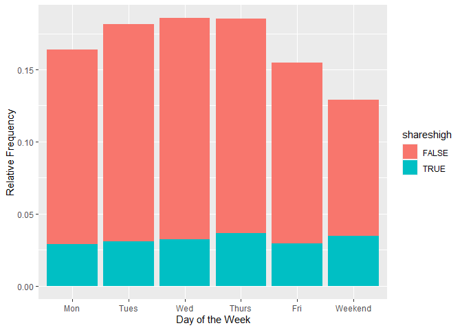

```r
ggplot(shareshigh, aes(x = Days_of_Week, fill = shareshigh)) +
  geom_bar(aes(y = (after_stat(count))/sum(after_stat(count)))) + xlab('Day of the Week') +
  ylab('Relative Frequency')
```

The above bar graphs are a visual representation of the contingency tables between weekends/weekdays and shareshigh and the days of the week and shareshigh.. Graphs can improve the stakeholders ability to interpret the results quickly.

```r
a <- table(shareshigh$Days_of_Week)
# a <- prop.table(table(shareshigh$Days_of_Week,
#                  shareshigh$shareshigh))
b <- as.data.frame(a)
colnames(b) <- c('Day of Week', 'Freq')
b <- filter(b, Freq == max(b$Freq))
d <- as.character(b[1,1])
g <- mutate(shareshigh,
                  Most_Freq = ifelse(Days_of_Week == d,
                                    'Most Freq Day',
                                    'Not Most Freq Day'
                                    ))
paste0(" For ",
        params$DataChannel, " ",
       d, " is the most frequent day of the week")
```

```
## [1] " For World Wed is the most frequent day of the week"
```

```r
table(shareshigh$shareshigh, g$Most_Freq)
```

```
##
##         Most Freq Day Not Most Freq Day
##   FALSE           904              3856
##   TRUE            191               947
```

The above contingency table compares shareshigh to the World day that occurs most frequently. This allows us to see if the most frequent day tends to have more shareshigh.

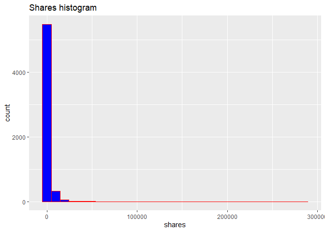

```r
## creates plotting object of shares
a <- ggplot(data_channel_train, aes(x=shares))

## histogram of shares
a+geom_histogram(color= "red", fill="blue")+ ggtitle("Shares histogram")
```

Above we can see the frequency distribution of shares of the World data channel. We should always see a long tail to the right because a small number of articles will get a very high number of shares. But looking at by looking at the distribution we can say how many shares most of these articles got.

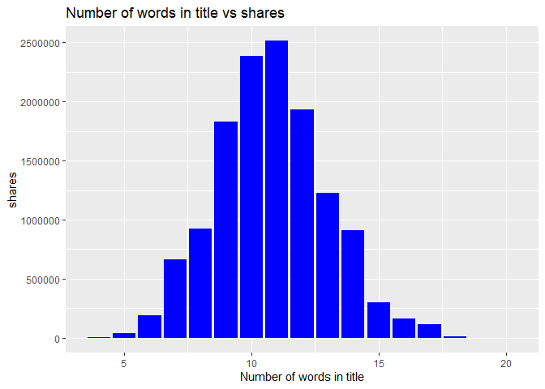

```r
## creates plotting object with number of words in title and shares
b<- ggplot(data_channel_train, aes(x=n.Title, y=shares))

## creates a bar chart with number of words in title and shares
b+ geom_col(fill="blue")+ ggtitle("Number of words in title vs shares") + labs(x="Number of words in title")
```

In the above graph we are looking at the number of shares based on how many words are in the title of the article. if we see a large peak on at the higher number of words it means for this data channel there were more shares on longer titles, and if we see a peak at smaller number of words then there were more shares on smaller titles.

```r
## makes correlation of every variable with shares
shares_correlations <- cor(data_channel_train)[1,] %>% sort()

shares_correlations
```

```
##              LDA_02           Avg.Words            Rate.Neg         Max.Neg.Pol
##        -0.099373019        -0.062391097        -0.052279145        -0.051859399
##        Rate.Nonstop Rate.Unique.Nonstop                 Wed     Global.Neg.Rate
##        -0.042400308        -0.033902734        -0.032142496        -0.029901810
##            Abs.Subj         Rate.Unique         Min.Pos.Pol         Avg.Pos.Pol
##        -0.028606904        -0.025468439        -0.019813814        -0.019719763
##         Avg.Neg.Pol                Tues                 Fri           n.Content
##        -0.016128863        -0.013208403        -0.012905279        -0.010597616
##         Avg.Min.Key       Min.Worst.Key         Max.Pos.Pol             n.Other
##        -0.004593800        -0.003092323        -0.002569626        -0.000939131
##       Avg.Worst.Key        Min.Best.Key         Min.Neg.Pol            Rate.Pos
##         0.001778954         0.003153378         0.004881212         0.005533450
##       Max.Worst.Key        Avg.Best.Key        Max.Best.Key         Global.Subj
##         0.005848402         0.009761670         0.010863308         0.013252937
##                 Sun                 Mon              LDA_00               Thurs
##         0.014978483         0.015442909         0.015545308         0.019575135
##             Min.Ref                 Sat              LDA_01     Global.Pos.Rate
##         0.021280690         0.021507038         0.022063438         0.024506080
##          Global.Pol               n.Key             Weekend             n.Links
##         0.025503692         0.026187838         0.026645339         0.031125119
##             n.Title         Avg.Max.Key          Title.Subj             Avg.Ref
##         0.033943861         0.035290853         0.035400800         0.036015140
##           Title.Pol             Max.Ref             Abs.Pol            n.Videos
##         0.036234541         0.036998246         0.037160568         0.037890391
##              LDA_04         Avg.Avg.Key            n.Images              LDA_03
##         0.044058564         0.070783591         0.075507471         0.087345018
##              shares
##         1.000000000
```

```r
## take the name of the highest correlated variable
highest_cor <-shares_correlations[52]  %>% names()

highest_cor
```

```
## [1] "LDA_03"
```

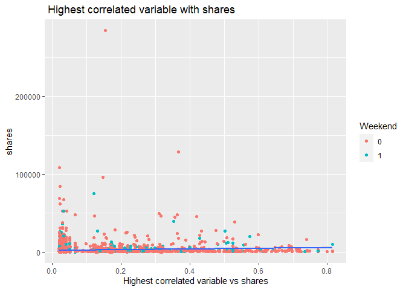

```r
## creats scatter plot looking at shares vs highest correlated variable
g <-ggplot(data_channel_train,  aes(y=shares, x= data_channel_train[[highest_cor]]))


g+ geom_point(aes(color=as.factor(Weekend))) +geom_smooth(method = lm) + ggtitle(" Highest correlated variable with shares") + labs(x="Highest correlated variable vs shares", color="Weekend")
```

The above graph looks at the relationship between shares and the variable with the highest correlation for the World data channel, and colored based on whether or not it is the weekend. because this is the most positively correlated variable we should always see an upward trend but the more correlated they are the more the dots will fall onto the line of best fit.

## Linear Regression

Linear regression is a tool with many applications available to data scientists. In linear regression, a linear relationship between one dependent variable and one or more independent variables is assumed. In computerized linear regression, many linear regressions between the response variable and the explanatory variable(s) are calculated. The regression that is considered the “best fit” is the least squares regression line. To determine the LSRL, the sum of the squared residuals is calculated for each regression. The best model is the regression that minimizes the sum of the squared residuals. Linear regression is used to predict responses for explanatory variable(s); it is also used to examine trends in the data.

### Linear regression 1

```r
## linear regression model using all predictors
set.seed(13)

linear_model_1 <- train( shares ~ .,
                         data = data_channel_train,
                         method = "lm",
                         preProcess = c("center", "scale"),
                         trControl = trainControl(method = "cv",
                                                  number = 5))

## prediction of test with model
linear_model_1_pred <- predict(linear_model_1, newdata = dplyr::select(data_channel_test, -shares))

## storing error of model on test set
linear_1_RMSE<- postResample(linear_model_1_pred, obs = data_channel_test$shares)
```

### Linear regression 2

```r
#Removed rate.Nonstop because it was only 1 and removed the days of the week.
linear_model_2 <- train( shares ~. - Rate.Nonstop - Mon
                         - Tues - Wed - Thurs - Fri - Sat
                         - Sun - Weekend,
                        data = data_channel_train,
                         method = "lm",
                         preProcess = c("center",
                                        "scale"),
                         trControl = trainControl(
                           method= "cv",
                           number = 5))
## prediction of test with model
linear_model_2_pred <- predict(linear_model_2, newdata = dplyr::select(data_channel_test, -shares))

## storing error of model on test set
linear_2_RMSE<- postResample(linear_model_2_pred, obs = data_channel_test$shares)
```

## Ensemble Models

### Random forest model

A random forest model is used in machine learning to generate predictions or classifications. This is done through generating many decision trees on many different samples and taking the average (regression) or the majority vote (classification). Some of the benefits to using random forest models are that over-fitting is minimized and the model works with the presence of categorical and continuous variables. With increased computer power and the increased knowledge in machine learning, random forest models will continue to grow in popularity.

```r
set.seed(10210526)
rfFit <- train(shares ~ .,
        data = data_channel_train,
        method = "rf",
        trControl = trainControl(method = "cv",
                                        number = 5),
        preProcess = c("center", "scale"),
        tuneGrid =
          data.frame(mtry = 1:sqrt(ncol(data_channel_train))))
rfFit_pred <- predict(rfFit, newdata = data_channel_test)
rfRMSE<- postResample(rfFit_pred, obs =
                            data_channel_test$shares)
```

### Boosted tree model

A decision tree makes a binary decision based on the value input. A boosted tree model generates a predictive model based on an ensemble of decision trees where better trees are generated based on the performance of previous trees. Our boosted tree model can be tuned using four different parameters: interaction.depth which defines the complexity of the trees being built, n.trees which defines the number of trees built (number of iterations), shrinkage which dictates the rate at which the algorithm learns, and n.minobsinnode which dictates the number of samples left to allow for a node to split.

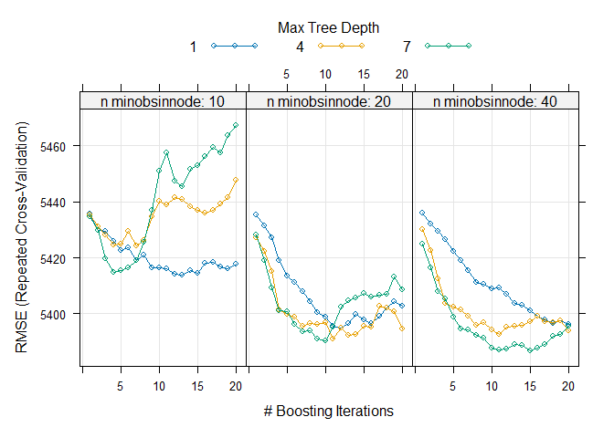

```r
## creates grid of possible tuning parameters
gbm_grid <-  expand.grid(interaction.depth = c(1,4,7),
  n.trees = c(1:20) ,
  shrinkage = 0.1,
  n.minobsinnode = c(10,20, 40))

## sets trainControl method
fit_control <- trainControl(method = "repeatedcv",
                            number = 5,
                            repeats= 1)

set.seed(13)

## trains to find optimal tuning parameters except it is giving weird parameters
gbm_tree_cv <- train(shares ~ . , data = data_channel_train,
                     method = "gbm",
                     preProcess = c("center", "scale"),
                     trControl = fit_control,
                     tuneGrid= gbm_grid,
                     verbose=FALSE)
## plot to visualize parameters
plot(gbm_tree_cv)
```

```r
## test set prediction
boosted_tree_model_pred <- predict(gbm_tree_cv, newdata = dplyr::select(data_channel_test, -shares), n.trees = 7)

## stores results
boosted_tree_RMSE <- postResample(boosted_tree_model_pred, obs = data_channel_test$shares)
```

## Comparison

```r
## creates a data frame of the four models RMSE on the
models_RMSE <- data.frame(linear_1_RMSE=linear_1_RMSE[1],
                         linear_2_RMSE=linear_2_RMSE[1],
                         rfRMSE=rfRMSE[1],
                          boosted_tree_RMSE =
                           boosted_tree_RMSE[1] )

models_RMSE
```

```
##      linear_1_RMSE linear_2_RMSE rfRMSE boosted_tree_RMSE
## RMSE       6099.04       6098.79 6083.5           6071.12
```

```r
## gets the name of the column with the smallest rmse
smallest_RMSE<-colnames(models_RMSE)[apply(models_RMSE,1,which.min)]

## declares the model with smallest RSME the winner
paste0(" For ",
        params$DataChannel, " ",
       smallest_RMSE, " is the winner")
```

```
## [1] " For World boosted_tree_RMSE is the winner"
```

## Automation

This is the code used to automate the rendering of each document based on the parameter of data_channel_is designated in the YAML.

```r
## creates a list of all 6 desired params from online
data_channel_is <- c("Lifestyle", "Entertainment", "Business", "Social.Media", "Tech", "World")

## creates the output file name
output_file <- paste0(data_channel_is, ".md")

#create a list for each channel with just the channel name parameter
params = lapply(data_channel_is, FUN = function(x){list(DataChannel = x)})

#put into a data frame
reports <- tibble(output_file, params)

## renders with params to all based on rows in reports
apply(reports, MARGIN=1, FUN = function(x){
## change first path to wherever yours is and output_dir to whatever folder you want it to output to
rmarkdown::render("C:/Users/Demetri/Documents/NCSU_masters/ST558/Repos/GitHub/ST_558_Project_2/_Rmd/ST_558_Project_2.Rmd",
                  output_format = "github_document",
                  output_dir = ".",
                  output_file = x[[1]],
                  params = x[[2]],
                  runtime = "static"
    )
  }
)
```